# Accessing data from web sources and data cleaning

Robin Lovelace University of Leeds, 2020-02-18

[figure not shown]

## Review of homework exercise: demo with RMarkdown then individual Q&A

We will be using these packages in this practical:

```r
library(sf)
library(stats19)
library(tidyverse)
```

## Accessing crowd-sourced data from OSM

- Navigate to https://overpass-turbo.eu/ and play with the interface to see what data is available from OpenStreetMap. Download data on highway=cycleway for Leeds from https://overpass-turbo.eu/
- Load the data in R and plot it with your favourite plotting package (e.g. `sf`, `mapview` or `tmap`)
- Bonus: now try to get the same data using the **osmdata** package

## Get official data with stats19

- Take a read of the stats19 README page and at least one of the articles on it here: https://docs.ropensci.org/stats19/
- Install and load the stats19 package as with one of the following commands:

```r
install.packages("stats19") # the stable version
remotes::install_github("ropensci/stats19") # the most recent 'development' version
```

- Show crashes involving pedestrians in Manchester by reproducing the following lines of code:

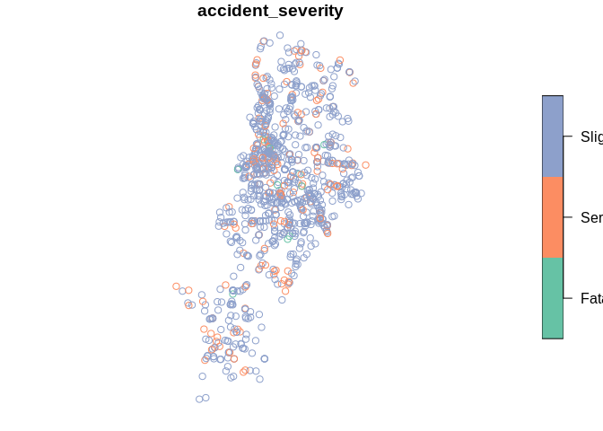

```r
library(sf)
library(stats19)
library(tidyverse)
crashes_2018 = get_stats19(year = 2018)
crashes_2018_sf = format_sf(crashes_2018)
crashes_manchester = crashes_2018_sf %>% filter(local_authority_district == "Manchester")
plot(crashes_manchester["accident_severity"])
```

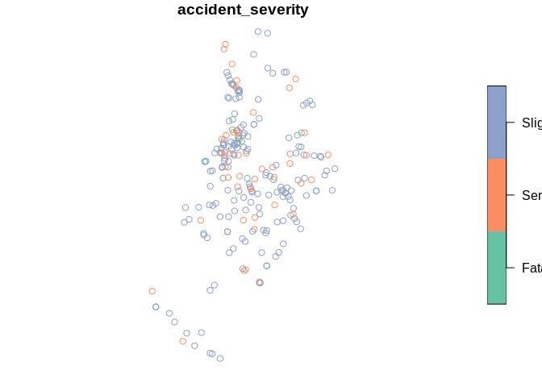

```r
casualties_2018 = get_stats19(year = 2018, type = "cas")
crashes_manchester = inner_join(crashes_manchester, casualties_2018)
pedestrian_casualties = crashes_manchester %>% filter(casualty_type == "Pedestrian")
plot(pedestrian_casualties["accident_severity"])
```

- Use the tmap package to create an interactive map of pedestrian casualties in Manchester, starting with the following commands (hint, use `tmaptools::palette_explorer()` and the argument `palette = "Reds"` in the function `tm_dots()`, for example, to change the default colour palette):

[figure not shown]

```r
library(tmap)
tmap_mode("view")
```

- Based on the documentation at https://docs.ropensci.org/stats19/:
  - Download data on road crashes in Great Britain in 2018
  - Filter crashes that happened in Leeds
- Bonus: make a map of pedestrian casualties in Leeds that shows the speed limit where pedestrians were hit. Explore the results in an interactive map. Where do you think the speed limit should be reduced based on this data?

The result should look something like this:

[figure not shown]

```r
crashes_leeds = crashes_2018_sf %>% filter(local_authority_district == "Leeds")
crashes_leeds = inner_join(crashes_leeds, casualties_2018)
pedestrian_casualties = crashes_leeds %>% filter(casualty_type == "Pedestrian")
tm_shape(pedestrian_casualties) +
  tm_dots("speed_limit")
```

- Bonus: what is the relationship between crash severity and the speed limit?
- Bonus: download and visualise the Leeds Bradford Cycle Superhighway data with these commands:

```r
library(osmdata)
data_osm = opq("leeds uk") %>%
  add_osm_feature(key = "name", value = "Cycle Superhighway 1") %>%
  osmdata_sf()
```

[figure not shown]

```r
# if the previous command fails, try:
data_osm = readRDS(url("https://github.com/ITSLeeds/TDS/releases/download/0.20.1/data_osm_cycle_superhighway.Rds"))
cycleway_100m_buffer = stplanr::geo_buffer(data_osm$osm_lines, dist = 100)
crashes_leeds_lon_lat = crashes_leeds %>% st_transform(4326)
crashes_near_cycle_superhighway = crashes_leeds_lon_lat[cycleway_100m_buffer, ]
tm_shape(data_osm$osm_lines) + tm_lines() +
  tm_shape(crashes_near_cycle_superhighway) + tm_dots("casualty_type")
```

- Filter crashes that happened within a 500 m buffer of the cycle infrastructure
- Do cyclists seem safer on the cycle superhighway?
- Bonus: pull down origin-destination data with the `pct` package hosted at: https://github.com/ITSLeeds/pct

## Getting data from the web

Read through Section [7.2](https://geocompr.robinlovelace.net/read-write.html#retrieving-data) and 7.3 of Geocomputation with R.

Complete Excersises 4, 5, 6 and 7 of the chapter

## Bonus 1: Geofabrik

Take a read of the documentation on the website https://itsleeds.github.io/geofabrik/

Reproduce the examples

Get all supermarkets in OSM for West Yorkshire

Identify all cycleways in West Yorkshire and, using the stats19 data you have already downloaded, identify all crashes that happened near them.

## Bonus 2: Getting data from statistics.gov.uk

Identify a region and zonal units of interest from http://geoportal.statistics.gov.uk/

- Read them into R as an `sf` object
- Join-on data from a non-geographic object
- Add a data access section to your in progress portfolio